# Entrega 1

Roberto Esteban Olivares

25/3/2021

# Introducción

##### En mi elección para el trabajo a realizar he escogido un dataframe que contiene todas las *estadisticas* de los jugadores del **videojuego** FIFA 19.

[figure not shown]

.

# Carga del Dataframe y Uso

```r
library(tidyverse)
fifa <- read_csv("data.csv")
```

#### A continuación seleccionamos *submuestras* de nuestro archivo para poder trabajar con ellas más tarde

```r
head(fifa)
```

```
## # A tibble: 6 x 89
##      X1     ID Name     Age Photo    Nationality Flag    Overall Potential Club
##   <dbl>  <dbl> <chr>  <dbl> <chr>    <chr>       <chr>     <dbl>     <dbl> <chr>
## 1     0 158023 L. Me~    31 https:/~ Argentina   https:~      94        94 FC B~
## 2     1  20801 Crist~    33 https:/~ Portugal    https:~      94        94 Juve~
## 3     2 190871 Neyma~    26 https:/~ Brazil      https:~      92        93 Pari~
## 4     3 193080 De Gea    27 https:/~ Spain       https:~      91        93 Manc~
## 5     4 192985 K. De~    27 https:/~ Belgium     https:~      91        92 Manc~
## 6     5 183277 E. Ha~    27 https:/~ Belgium     https:~      91        91 Chel~
## # ... with 79 more variables: Club Logo <chr>, Value <chr>, Wage <chr>,
## #   Special <dbl>, Preferred Foot <chr>, International Reputation <dbl>,
## #   Weak Foot <dbl>, Skill Moves <dbl>, Work Rate <chr>, Body Type <chr>,
## #   Real Face <chr>, Position <chr>, Jersey Number <dbl>, Joined <chr>,
## #   Loaned From <chr>, Contract Valid Until <chr>, Height <chr>, Weight <chr>,
## #   LS <chr>, ST <chr>, RS <chr>, LW <chr>, LF <chr>, CF <chr>, RF <chr>,
## #   RW <chr>, LAM <chr>, CAM <chr>, RAM <chr>, LM <chr>, LCM <chr>, CM <chr>,
## #   RCM <chr>, RM <chr>, LWB <chr>, LDM <chr>, CDM <chr>, RDM <chr>, RWB <chr>,
## #   LB <chr>, LCB <chr>, CB <chr>, RCB <chr>, RB <chr>, Crossing <dbl>,
## #   Finishing <dbl>, HeadingAccuracy <dbl>, ShortPassing <dbl>, Volleys <dbl>,
## #   Dribbling <dbl>, Curve <dbl>, FKAccuracy <dbl>, LongPassing <dbl>,
## #   BallControl <dbl>, Acceleration <dbl>, SprintSpeed <dbl>, Agility <dbl>,
## #   Reactions <dbl>, Balance <dbl>, ShotPower <dbl>, Jumping <dbl>,
## #   Stamina <dbl>, Strength <dbl>, LongShots <dbl>, Aggression <dbl>,
## #   Interceptions <dbl>, Positioning <dbl>, Vision <dbl>, Penalties <dbl>,
## #   Composure <dbl>, Marking <dbl>, StandingTackle <dbl>, SlidingTackle <dbl>,
## #   GKDiving <dbl>, GKHandling <dbl>, GKKicking <dbl>, GKPositioning <dbl>,
## #   GKReflexes <dbl>, Release Clause <chr>
```

#### Una submuetra con la que vamos a trabajar va a ser con los **nombres**, **edades** y **potencial** de los jugadores

```r
# Podemos seleccionar las columnas que escojamos de un dataset
info<-select(fifa, Name,Age,Potential)
info
```

```
## # A tibble: 18,207 x 3
##    Name                Age Potential
##    <chr>             <dbl>     <dbl>
##  1 L. Messi             31        94
##  2 Cristiano Ronaldo    33        94
##  3 Neymar Jr            26        93
##  4 De Gea               27        93
##  5 K. De Bruyne         27        92
##  6 E. Hazard            27        91
##  7 L. Modric            32        91
##  8 L. Suárez            31        91
##  9 Sergio Ramos         32        91
## 10 J. Oblak             25        93
## # ... with 18,197 more rows
```

#### Otra *submuetra* con la que vamos a trabajar va a ser el **nombre** de los **jugadores**, **club** y su **altura**

```r
info_height<-select(fifa,Name,Club,Height)
info_height
```

```
## # A tibble: 18,207 x 3
##    Name              Club                Height
##    <chr>             <chr>               <chr>
##  1 L. Messi          FC Barcelona        5'7
##  2 Cristiano Ronaldo Juventus            6'2
##  3 Neymar Jr         Paris Saint-Germain 5'9
##  4 De Gea            Manchester United   6'4
##  5 K. De Bruyne      Manchester City     5'11
##  6 E. Hazard         Chelsea             5'8
##  7 L. Modric         Real Madrid         5'8
##  8 L. Suárez         FC Barcelona        6'0
##  9 Sergio Ramos      Real Madrid         6'0
## 10 J. Oblak          Atlético Madrid     6'2
## # ... with 18,197 more rows
```

#### Usando la funcion *arrange* vamos a ordenar datos

```r
# Ordenamos los jugadores segun su altura en sentido ascendente
arrange(fifa, Height)
```

```
## # A tibble: 18,207 x 89
##       X1     ID Name     Age Photo   Nationality  Flag   Overall Potential Club
##    <dbl>  <dbl> <chr>  <dbl> <chr>   <chr>        <chr>    <dbl>     <dbl> <chr>
##  1  6275 237994 N. Ba~    20 https:~ Argentina    https~      69        82 San ~
##  2  6584 232951 H. Na~    23 https:~ Japan        https~      69        72 Kash~
##  3 17157 242566 K. Ya~    23 https:~ Japan        https~      55        61 Shon~
##  4    15 211110 P. Dy~    24 https:~ Argentina    https~      89        94 Juve~
##  5    25 231747 K. Mb~    19 https:~ France       https~      88        95 Pari~
##  6    69 184432 Azpil~    28 https:~ Spain        https~      86        86 Chel~
##  7    72 180206 M. Pj~    28 https:~ Bosnia Herz~ https~      86        86 Juve~
##  8    75 135507 Ferna~    33 https:~ Brazil       https~      86        86 Manc~
##  9    84 204485 R. Ma~    27 https:~ Algeria      https~      85        85 Manc~
## 10   114 212198 Bruno~    23 https:~ Portugal     https~      84        88 Spor~
## # ... with 18,197 more rows, and 79 more variables: Club Logo <chr>,
## #   Value <chr>, Wage <chr>, Special <dbl>, Preferred Foot <chr>,
## #   International Reputation <dbl>, Weak Foot <dbl>, Skill Moves <dbl>,
## #   Work Rate <chr>, Body Type <chr>, Real Face <chr>, Position <chr>,
## #   Jersey Number <dbl>, Joined <chr>, Loaned From <chr>,
## #   Contract Valid Until <chr>, Height <chr>, Weight <chr>, LS <chr>, ST <chr>,
## #   RS <chr>, LW <chr>, LF <chr>, CF <chr>, RF <chr>, RW <chr>, LAM <chr>,
## #   CAM <chr>, RAM <chr>, LM <chr>, LCM <chr>, CM <chr>, RCM <chr>, RM <chr>,
## #   LWB <chr>, LDM <chr>, CDM <chr>, RDM <chr>, RWB <chr>, LB <chr>, LCB <chr>,
## #   CB <chr>, RCB <chr>, RB <chr>, Crossing <dbl>, Finishing <dbl>,
## #   HeadingAccuracy <dbl>, ShortPassing <dbl>, Volleys <dbl>, Dribbling <dbl>,
## #   Curve <dbl>, FKAccuracy <dbl>, LongPassing <dbl>, BallControl <dbl>,
## #   Acceleration <dbl>, SprintSpeed <dbl>, Agility <dbl>, Reactions <dbl>,
## #   Balance <dbl>, ShotPower <dbl>, Jumping <dbl>, Stamina <dbl>,
## #   Strength <dbl>, LongShots <dbl>, Aggression <dbl>, Interceptions <dbl>,
## #   Positioning <dbl>, Vision <dbl>, Penalties <dbl>, Composure <dbl>,
## #   Marking <dbl>, StandingTackle <dbl>, SlidingTackle <dbl>, GKDiving <dbl>,
## #   GKHandling <dbl>, GKKicking <dbl>, GKPositioning <dbl>, GKReflexes <dbl>,
## #   Release Clause <chr>
```

#### Usando la opción *desc()*, volveremos a ordenar los jugadores esta vez en sentido **descendente**.

```r
# Podemos usar desc() para tener orden descendente
arrange(fifa, desc(Height))
```

```
## # A tibble: 18,207 x 89
##       X1     ID Name     Age Photo    Nationality Flag   Overall Potential Club
##    <dbl>  <dbl> <chr>  <dbl> <chr>    <chr>       <chr>    <dbl>     <dbl> <chr>
##  1 11614 199321 T. Ho~    26 https:/~ Czech Repu~ https~      64        68 Gill~
##  2 17927 243796 D. Ho~    22 https:/~ Croatia     https~      51        61 Vejl~
##  3  4189 224836 V. Mi~    21 https:/~ Serbia      https~      71        79 SPAL
##  4  4281 192613 C. Pa~    31 https:/~ Romania     https~      71        71 Nott~
##  5  9559 243628 A. Vu~    22 https:/~ Serbia      https~      66        72 Waas~
##  6 11403 218212 A. No~    24 https:/~ Netherlands https~      64        69 Fogg~
##  7 11903 243675 K. Sc~    18 https:/~ Netherlands https~      64        78 FC E~
##  8 12494 215408 A. Ch~    28 https:/~ England     https~      63        63 Pete~
##  9 14542 237015 M. Qv~    25 https:/~ Denmark     https~      61        64 AC H~
## 10 16923 243387 S. Br~    17 https:/~ Sweden      https~      56        78 AIK
## # ... with 18,197 more rows, and 79 more variables: Club Logo <chr>,
## #   Value <chr>, Wage <chr>, Special <dbl>, Preferred Foot <chr>,
## #   International Reputation <dbl>, Weak Foot <dbl>, Skill Moves <dbl>,
## #   Work Rate <chr>, Body Type <chr>, Real Face <chr>, Position <chr>,
## #   Jersey Number <dbl>, Joined <chr>, Loaned From <chr>,
## #   Contract Valid Until <chr>, Height <chr>, Weight <chr>, LS <chr>, ST <chr>,
## #   RS <chr>, LW <chr>, LF <chr>, CF <chr>, RF <chr>, RW <chr>, LAM <chr>,
## #   CAM <chr>, RAM <chr>, LM <chr>, LCM <chr>, CM <chr>, RCM <chr>, RM <chr>,
## #   LWB <chr>, LDM <chr>, CDM <chr>, RDM <chr>, RWB <chr>, LB <chr>, LCB <chr>,
## #   CB <chr>, RCB <chr>, RB <chr>, Crossing <dbl>, Finishing <dbl>,
## #   HeadingAccuracy <dbl>, ShortPassing <dbl>, Volleys <dbl>, Dribbling <dbl>,
## #   Curve <dbl>, FKAccuracy <dbl>, LongPassing <dbl>, BallControl <dbl>,
## #   Acceleration <dbl>, SprintSpeed <dbl>, Agility <dbl>, Reactions <dbl>,
## #   Balance <dbl>, ShotPower <dbl>, Jumping <dbl>, Stamina <dbl>,
## #   Strength <dbl>, LongShots <dbl>, Aggression <dbl>, Interceptions <dbl>,
## #   Positioning <dbl>, Vision <dbl>, Penalties <dbl>, Composure <dbl>,
## #   Marking <dbl>, StandingTackle <dbl>, SlidingTackle <dbl>, GKDiving <dbl>,
## #   GKHandling <dbl>, GKKicking <dbl>, GKPositioning <dbl>, GKReflexes <dbl>,
## #   Release Clause <chr>
```

# Analisis de Variables numericas

[figure not shown]

.

#### A continuación vamos a sacar el *maximo* sobre el que tenemos más valores en nuestro csv, de la columna *edad*. Por lo tanto tendremos la edad del jugador más longevo

```r
max(fifa$Age)
```

```
## [1] 45
```

#### A continuación vamos a sacar el *minimo* sobre uno de los valores de nuestro csv, de la columna *edad*. Por lo tanto tendremos la edad del jugador más joven. Utilizaré la funcióin **min()**

```r
min(fifa$Age)
```

```
## [1] 16
```

#### Tambien podemos sacar la *mediana* de los potenciales de todos los jugadores, utilizando la función **median()**.

```r
median(fifa$Potential)
```

```
## [1] 71
```

#### También utilizaré la función **mean()**. La media de los potenciales totales son:

```r
mean(fifa$Potential)
```

```
## [1] 71.3073
```

#### También tenemos la función *summary* la cual nos permite tener todos los datos necesarios de una variable, vamos a ver alguno ejemplo con ella.

#### Primero lo vemos con la **edad**.

```r
summary(fifa$Age)
```

```
##    Min. 1st Qu.  Median    Mean 3rd Qu.    Max.
##   16.00   21.00   25.00   25.12   28.00   45.00
```

#### Ahora vamos a verlo con el **dribling** de los jugadores

```r
summary(fifa$Dribbling)
```

```
##    Min. 1st Qu.  Median    Mean 3rd Qu.    Max.    NA's
##    4.00   49.00   61.00   55.37   68.00   97.00      48
```

# Realización de gráficos de variables y boxplots

[figure not shown]

.

#### Voy a realizar un *boxplot* de las estadisticas de los **penaltis** de cada jugador

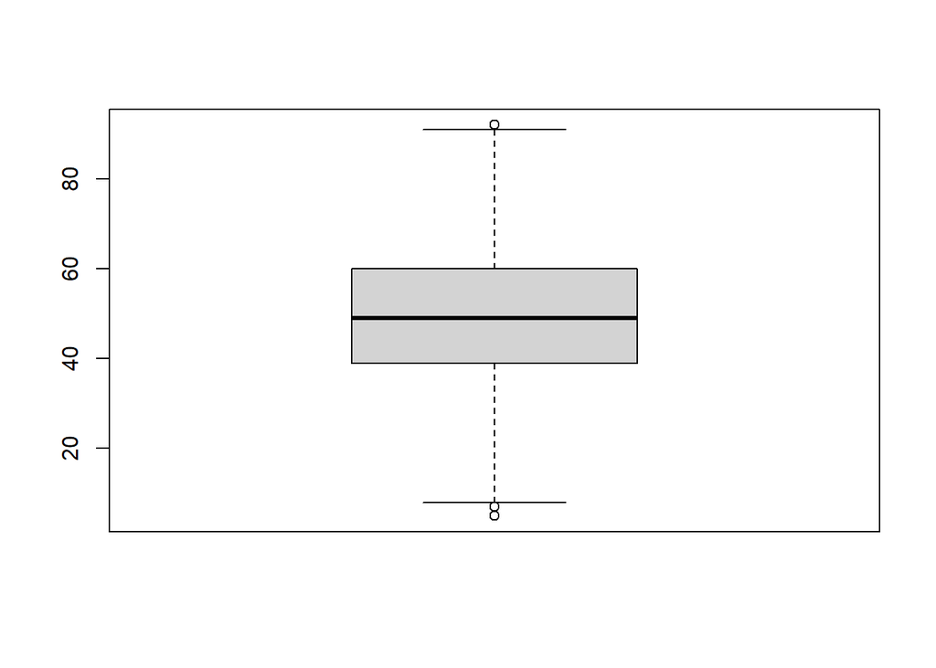

```r
penalty<-fifa$Penalties
boxplot(penalty)
```

#### Para variables **cuantitativas** podemos recurrir a los histogramas, que nos agrupan los datos en barras para su representación:

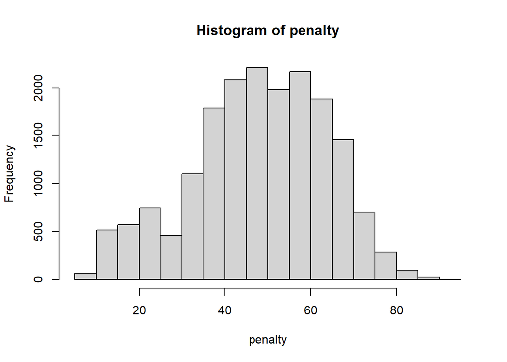

```r
hist(penalty)
```

#### El histograma anteriormente realizado nos puesta los datos sobre las estadisticas que tiene cada jugador para lanzar penaltis en el juego, y vemos que la mayoria de ellos están en un rango de 70-40 de acierto.

#### Podemos comentar que es un poco simetrico el histograma aunque tienede a tner un poco de Asimetría negativa

#### Otro *histograma* sobre las edades sería

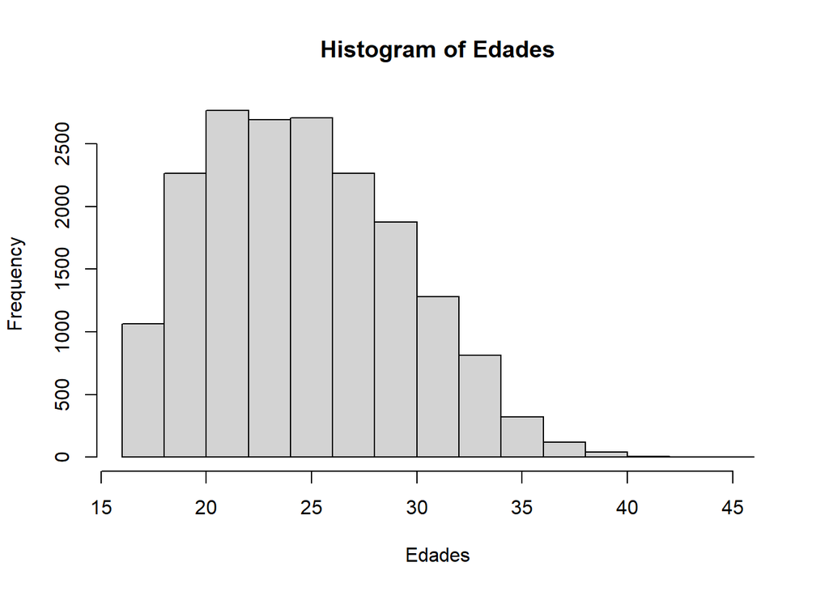

```r
Edades<-(fifa$Age)
hist(Edades)
```

##### En el histograma anteriormente realizado podemos objervar que en el juego abundan jugadores con edades entre 20 y 27 años aproximadamente.

##### Podemos comentar que este histograma tiene Asimetría positiva, ya que la cola de la distribucion se alarga para valores superiores a la media.

##### También vemos que tenemos la opción de crear un *diagrama de barras* y así poder ver como ser reparten los jugadores según si son **diestros** o **zurdos**. En nuestro diagrama vemos que hay más jugadores diestros que zurdos.

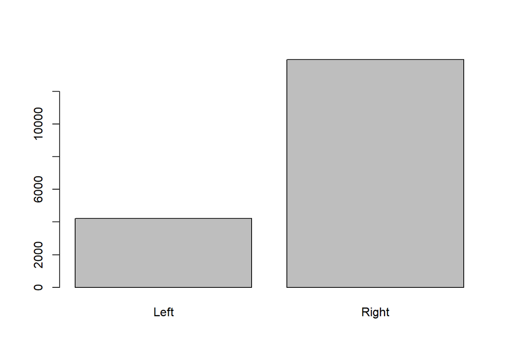

```r
barplot(table(fifa$`Preferred Foot`))
```

#### También voy a añadir un *diagrama de sectores* sobre las **edades** , y así ver sobre que edad tenemos mas jugadores

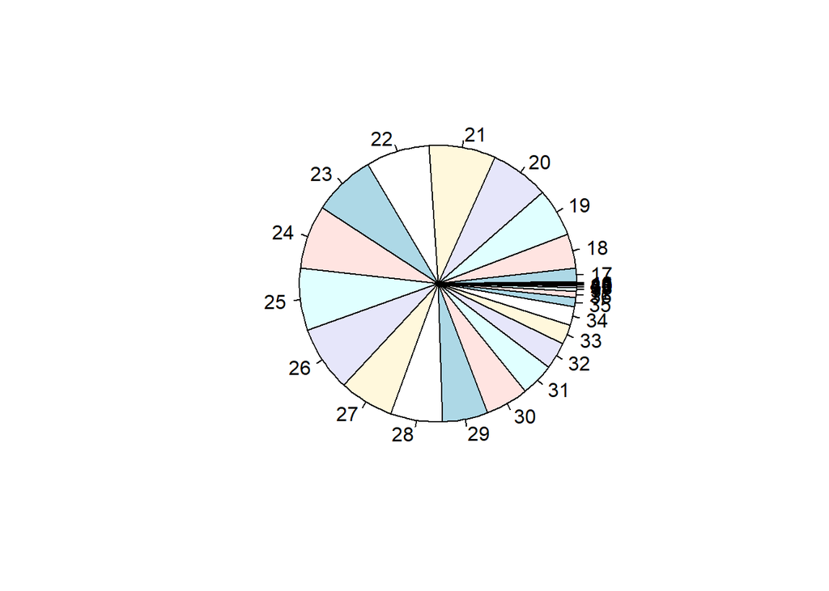

```r
frecuencias<-table(fifa$Age)
pie(frecuencias)
```

##### Podemos observar que de las edades 20 a la 27 tienen una forma muy similar por lo tanto podemos ver que el porcentaje es muy similar en cada una de las edades.

#### Y también voy a realizar un *diagrama de barras* sobre las frecuencias de acierto de cada jugador para los **penaltis**.

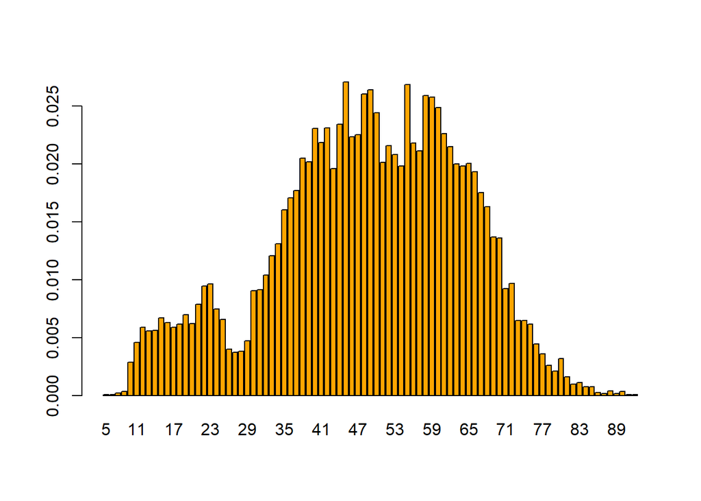

```r
barplot(prop.table(table(fifa$Penalties)),col =c("orange"))
```

##### Con el anterior diagrama de barras podemos observar que las frecuencias mas habituales para lanzar penaltis y marcarlos en el fifa esta entre un 40 y un 70 las stats.

# Analizar relaciones entre variables

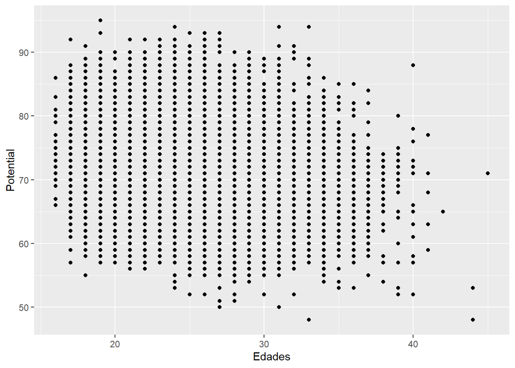

```r
library(ggplot2)
ggplot(data = fifa) +
  geom_point(mapping = aes(x =Edades , y = Potential))
```

##### En ese primer ejemplo de gráficos con ggplot2, he comparado las edades contra los potenciales de cada jugador , podemos observar que también tiene algunos valores atípcios a la derecha del gráfico representado

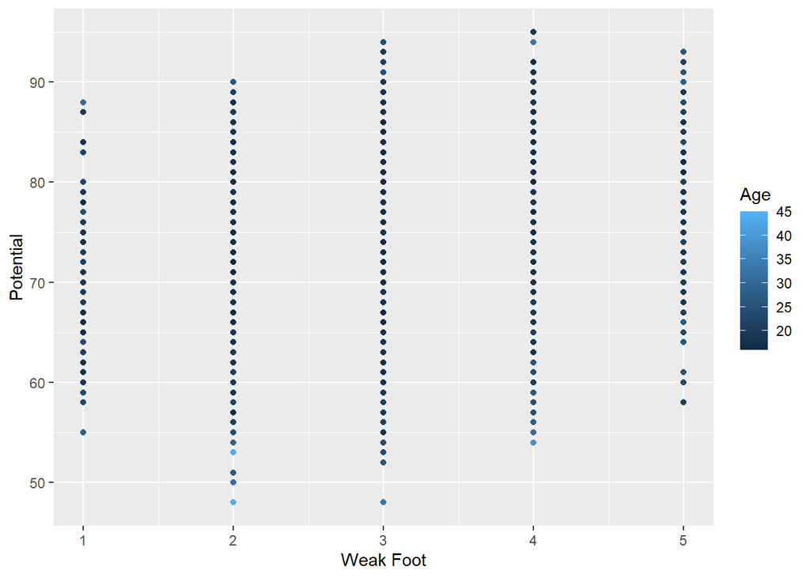

```r
ggplot(data = fifa) +
  geom_point(mapping = aes(y = Potential, x =`Weak Foot`,color=Age))
```

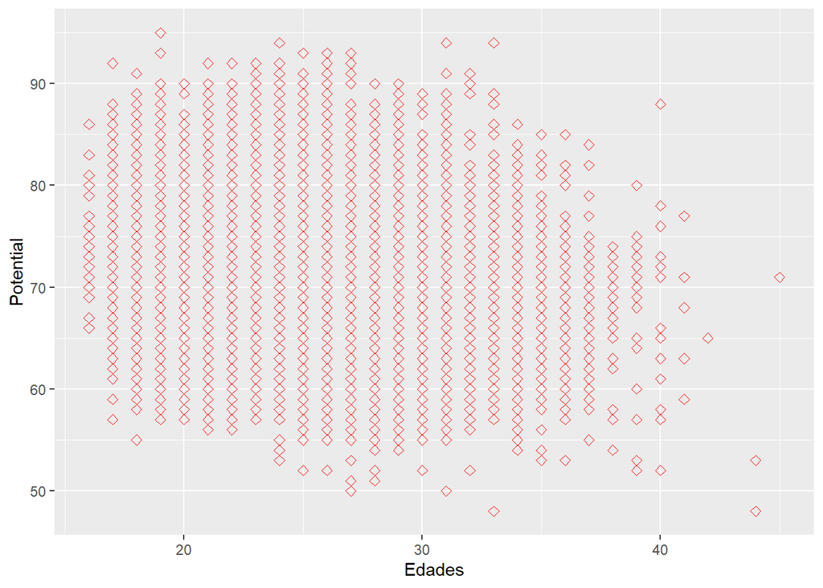

```r
ggplot(data = fifa) +
  geom_point(mapping = aes(x = Edades, y = Potential), color = "red", size=1.8, shape=5)
```

##### Como vemos también tenemos algunas opciones en dichos gráficos que nos permiten añadir formas y colores a los diferentes puntos.

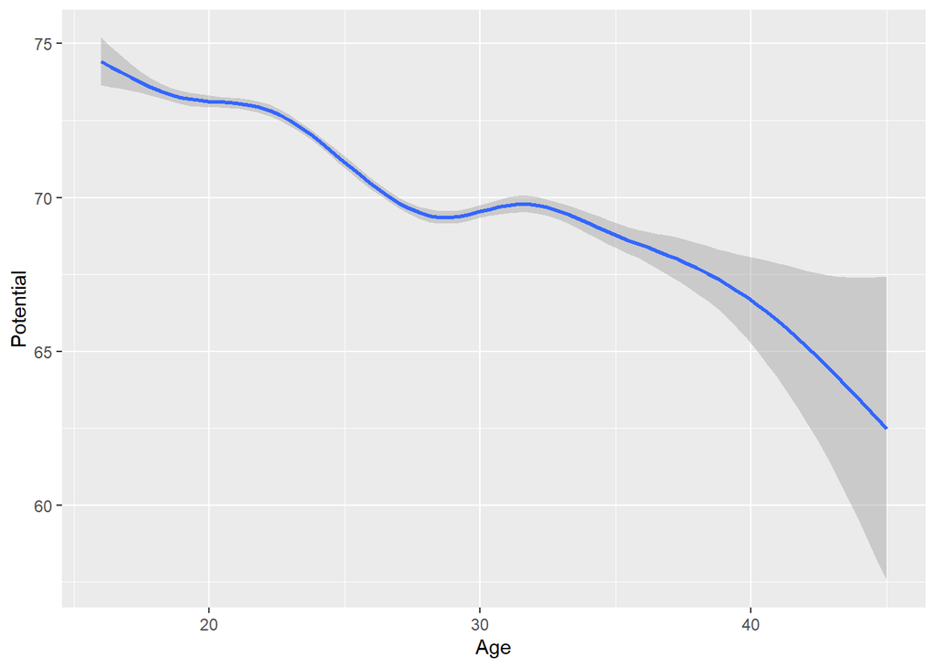

```r
ggplot(data = fifa) +
  geom_smooth(mapping = aes(x = Age, y = Potential))
```

#### Podemos combinar los dos anteriores vistos

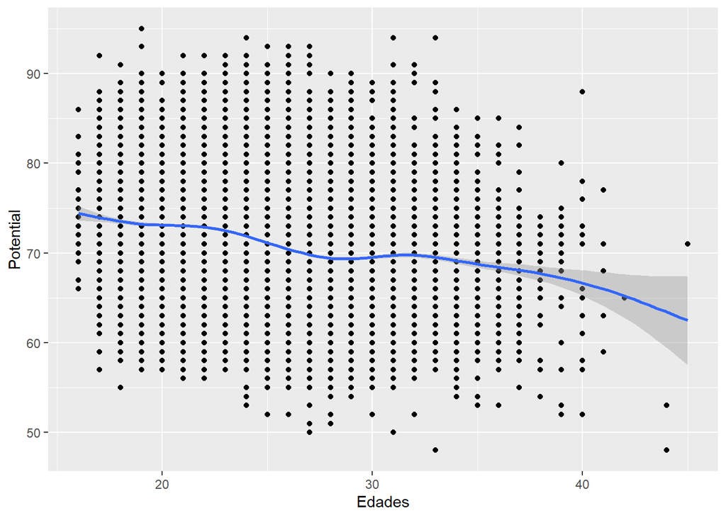

```r
ggplot(data = fifa) +
  geom_point(mapping = aes(x = Edades, y = Potential)) +
  geom_smooth(mapping = aes(x = Edades, y = Potential))
```

#### Tenemos también la posibilidad de crear *histogramas*, añadirlos **colores**

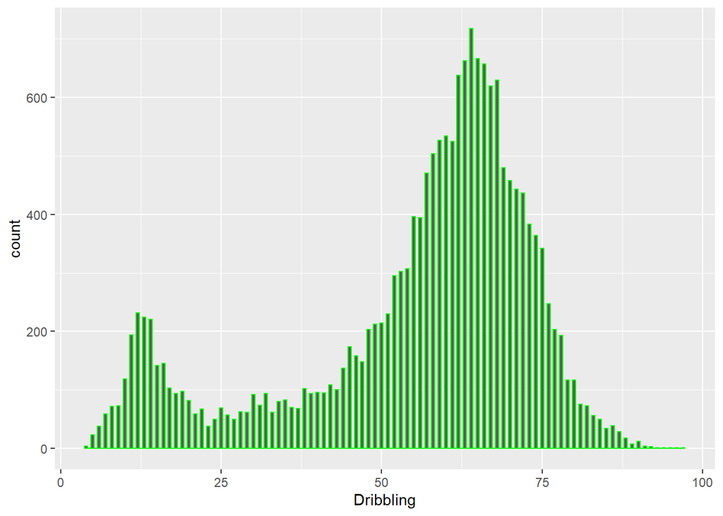

```r
ggplot(data = fifa) +
  geom_histogram(mapping = aes(x = Dribbling), color="green", binwidth = 0.50)
```

##### Observamos que la mayoria de los jugadores tienen un Dribbling de 65-70. También podemos observar con el histograma anterior que tiene asimetria negativa, ya que la cola se arga para valores inferiores a la media

#### Uso de Coordenadas:

#### Los gráficos admiten cambios de coordenadas, para cambiar un gráfico de vertical a horizontal, o cambiar a coordenadas polares y hacerlo circular, con las opciones *coord_flip() y coord_polar()*, respectivamente.

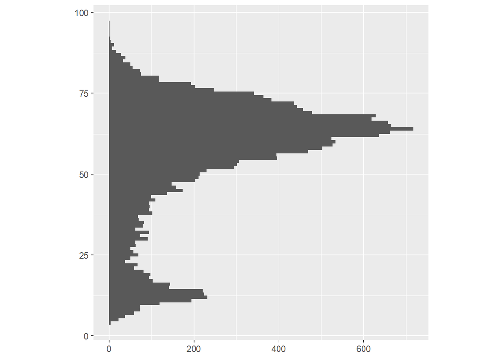

```r
bar <- ggplot(data = fifa) +
  geom_bar(
    mapping = aes(x = fifa$Dribbling, fill = Age),
    show.legend = FALSE,
    width = 1
  ) +
  theme(aspect.ratio = 1) +
  labs(x = NULL, y = NULL)

bar + coord_flip()
```

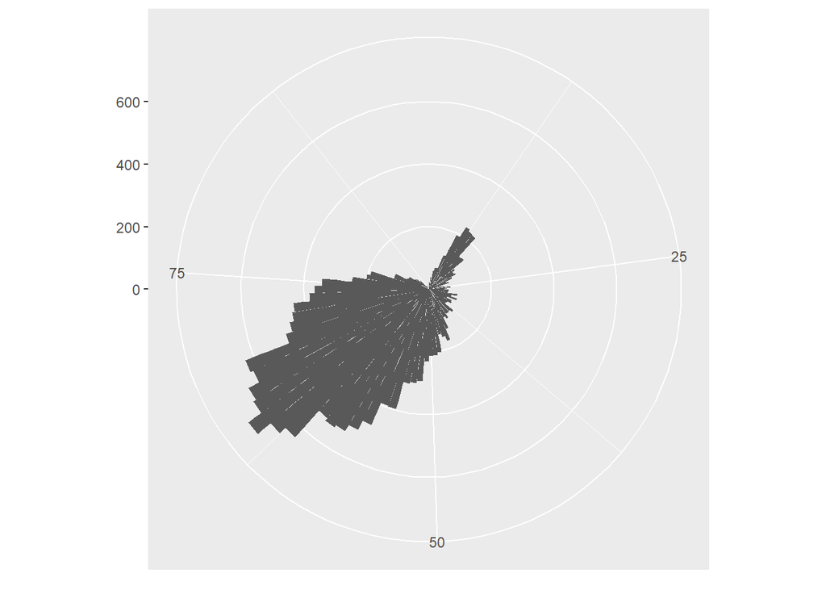

```r
# O a un diagram circular
bar + coord_polar()
```

#### A continuación voy a utilizar la función *mutate()*. Y asi también poder serparar una columna en tres categorias para poder representarla luego.

#### Con la función *mutate()* podemos computar tranformaciones de variables en un data frame.

#### Lo que he hecho es sobreescribir mi dataframe *fifa* para que tengas la nueva columna que acabamos de realizar.

```r
fifa<-fifa%>%
  mutate(drib_categorico = case_when(Dribbling < 50 ~ "bajo",
                                          Dribbling >= 50 & Dribbling < 80
                                     ~"medio",TRUE ~ "alto"))
```

#### A continuación voy a volver a utilizar la función *mutate()*. Y asi también poder serparar una columna en tres categorias para poder representarla luego.

#### Con la función *mutate()* podemos computar tranformaciones de variables en un data frame.

#### Lo que he hecho también es sobreescribir mi dataframe *fifa* para que tengas la nueva columna que acabamos de realizar, como habiamos realizado anteriormente.

```r
fifa<-fifa%>%
  mutate(clasificacion_edad = case_when(Age < 21 ~ "Joven",
                                          Age >= 21 & Age < 35
                                     ~"Perfecta",TRUE ~ "Retirada")
)
```

#### Entonces ahora podemos realizar los graficos de las nuevas columnas y asi poder visualizarlo mejor.

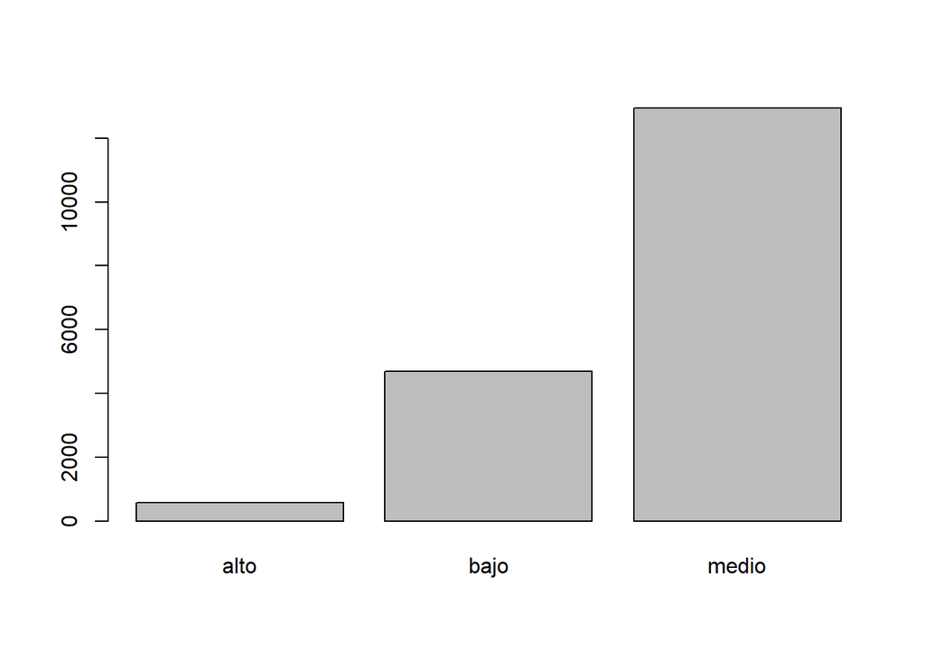

```r
barplot(table(fifa$drib_categorico))
```

##### Podemos ver que hay más jugadores con un dribling medio, sin embargo tenemos pocos jugadores con dribling altos.

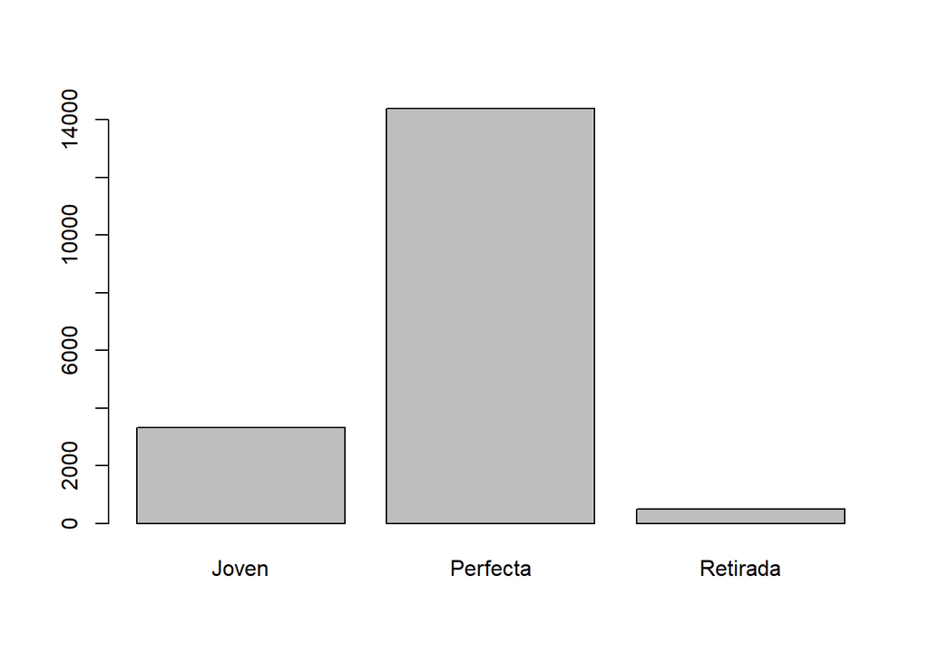

```r
barplot(table(fifa$clasificacion_edad))
```

##### Según nuestra clasificación que realizamos de la edad, hya mayoria de jugadores en la edad perfecta, y jugadores con edad a punto de retirarse hay pocos jugadores.